# TD 1 Balanin R in Mab (2023-11-11)

Lundi 13 Novembre, 2023

https://OlivierSo26.github.io/RinMab/ rmarkdown::render(“TD1bis_Balanin.Rmd”, output_file = “RinMab/index.html”) # Edition .Html

```r
rm(list = ls())
getwd()
```

```
## [1] "D:/OneDrive - etu.univ-lyon1.fr/STATS/Stat_in_MAB/RinMAB"
```

```r
# Lister les Fichiers de mon Répertoire
list.files(getwd())
```

```
##  [1] "Balanin.csv"         "Convertisseur.R"     "css"                 "desktop.ini"
##  [5] "GlossRinMAB2023.pdf" "index.html"          "RinMab"              "TD1_Balanin.html"
##  [9] "TD1_MAB_2023.pdf"    "TD1bis_Balanin.html" "TD1bis_Balanin.pdf"  "TD1bis_Balanin.R"
## [13] "TD1bis_Balanin.Rmd"  "TD2_MAB_2023.pdf"    "Tortoise"
```

```r
bal <- read.table("Balanin.csv", sep = ",", h=T )
# Dimension de la table ?
dim(bal)
```

```
## [1] 295   6
```

```r
nrow(bal)
```

```
## [1] 295
```

```r
length(bal)
```

```
## [1] 6
```

```r
summary(bal)
```

```
##     espece              sexe               poids             LR              LC
##  Length:295         Length:295         Min.   : 7.90   Min.   :2.500   Min.   :4.200
##  Class :character   Class :character   1st Qu.:26.45   1st Qu.:3.400   1st Qu.:6.200
##  Mode  :character   Mode  :character   Median :35.40   Median :3.800   Median :6.800
##                                        Mean   :35.95   Mean   :4.494   Mean   :6.815
##                                        3rd Qu.:45.50   3rd Qu.:5.500   3rd Qu.:7.300
##                                        Max.   :67.40   Max.   :9.400   Max.   :9.100
##     parasite
##  Min.   :0.000
##  1st Qu.:0.000
##  Median :1.000
##  Mean   :1.139
##  3rd Qu.:2.000
##  Max.   :6.000
```

```r
# Afficher les noms de Colonnes ?
names(bal)
```

```
## [1] "espece"   "sexe"     "poids"    "LR"       "LC"       "parasite"
```

```r
head(bal)
```

|  | espece | sexe | poids | LR | LC | parasite |
| --- | --- | --- | --- | --- | --- | --- |
| 1 | E | F | 59.0 | 8.3 | 8.6 | 2 |
| 2 | E | F | 48.6 | 8.3 | 8.5 | 2 |
| 3 | E | F | 54.8 | 8.9 | 8.7 | 2 |
| 4 | E | F | 49.1 | 7.4 | 8.4 | 1 |
| 5 | E | F | 60.1 | 8.6 | 8.9 | 1 |
| 6 | E | F | 55.1 | 8.4 | 8.7 | 2 |

```r
# PLUS PRECIS

# CLASS VS MODE ?
class(bal) # => OBJET
```

```
## [1] "data.frame"
```

```r
mode(bal) # => TYPE des Données
```

```
## [1] "list"
```

```r
class(bal$espece)
```

```
## [1] "character"
```

```r
mode(bal$espece)
```

```
## [1] "character"
```

```r
# QUE FAIRE DES CHAR ?
### Ils sont ne CHAR, en quoi dois-je les convertir et Comment ?
### Convertir CHAR en FACTOR
bal$sexe <- as.factor(bal$sexe)
bal$espece <- as.factor(bal$espece)

## COMPTER NB MALES / FEMELLES ?
table(bal$sexe)
```

```
##
##   F   M
## 167 128
```

```r
### NB SEXE DE CHAQUE ESPECE
table(bal$sexe, bal$espece)
```

```
##
##      E  G  P  V
##   F 23 80 30 34
##   M 29 35 34 30
```

# EXTRACTION DE DONNEES

## Créer 1 Vecteur par Espèce (= Filtrer 1 Attribut)

**Details Vecteurs**

```r
E <- bal[bal$espece == "E",] ; head(E, 2L) # Plus lisible dans une formule
```

|  | espece | sexe | poids | LR | LC | parasite |
| --- | --- | --- | --- | --- | --- | --- |
| 1 | E | F | 59.0 | 8.3 | 8.6 | 2 |
| 2 | E | F | 48.6 | 8.3 | 8.5 | 2 |

```r
G <- bal[bal$espece == "G",] ; head(G, 2L)
```

|  | espece | sexe | poids | LR | LC | parasite |
| --- | --- | --- | --- | --- | --- | --- |
| 24 | G | F | 13.7 | 4.1 | 5.2 | 1 |
| 25 | G | F | 26.3 | 5.2 | 5.8 | 1 |

```r
# ou Alternative Possible => SUBSET(x, subset, ...)
P <- subset(bal, bal$espece == "P") ; head(P, 2L)
```

|  | espece | sexe | poids | LR | LC | parasite |
| --- | --- | --- | --- | --- | --- | --- |
| 104 | P | F | 40.0 | 4.5 | 6.9 | 0 |
| 105 | P | F | 48.4 | 4.2 | 7.4 | 2 |

```r
V <- subset(bal, bal$espece == "V") ; head(V, 2L)
```

|  | espece | sexe | poids | LR | LC | parasite |
| --- | --- | --- | --- | --- | --- | --- |
| 134 | V | F | 41.3 | 4.1 | 7 | 3 |
| 135 | V | F | 41.5 | 3.7 | 7 | 2 |

## Créer 1 Vecteur par Espèce et par Sexe (= Filtrer 2 Attributs)

```r
EM <- bal[bal$espece == "E" & bal$sexe == "M",] ; head(EM, 2L)
```

|  | espece | sexe | poids | LR | LC | parasite |
| --- | --- | --- | --- | --- | --- | --- |
| 168 | E | M | 51.5 | 3.7 | 8.4 | 1 |
| 169 | E | M | 44.3 | 3.7 | 8.4 | 0 |

```r
GM <- bal[bal$espece == "G" & bal$sexe == "M",] ; head(GM, 2L)
```

|  | espece | sexe | poids | LR | LC | parasite |
| --- | --- | --- | --- | --- | --- | --- |
| 197 | G | M | 25.3 | 3.2 | 6.1 | 0 |
| 198 | G | M | 20.7 | 3.2 | 6.0 | 0 |

```r
PM <- bal[bal$espece == "P" & bal$sexe == "M",] ; head(PM, 2L)
```

|  | espece | sexe | poids | LR | LC | parasite |
| --- | --- | --- | --- | --- | --- | --- |
| 232 | P | M | 55.6 | 3.4 | 7.6 | 0 |
| 233 | P | M | 47.1 | 3.8 | 7.4 | 1 |

```r
VM <- bal[bal$espece == "V" & bal$sexe == "M",] ; head(VM, 2L)
```

|  | espece | sexe | poids | LR | LC | parasite |
| --- | --- | --- | --- | --- | --- | --- |
| 266 | V | M | 34.5 | 3 | 6.5 | 0 |
| 267 | V | M | 36.2 | 3 | 6.9 | 0 |

```r
EF <- subset(bal, bal$espece == "E" & bal$sexe == "F") ; head(EF, 2L)
```

|  | espece | sexe | poids | LR | LC | parasite |
| --- | --- | --- | --- | --- | --- | --- |
| 1 | E | F | 59.0 | 8.3 | 8.6 | 2 |
| 2 | E | F | 48.6 | 8.3 | 8.5 | 2 |

```r
GF <- subset(bal, bal$espece == "G" & bal$sexe == "F") ; head(GF, 2L)
```

|  | espece | sexe | poids | LR | LC | parasite |
| --- | --- | --- | --- | --- | --- | --- |
| 24 | G | F | 13.7 | 4.1 | 5.2 | 1 |
| 25 | G | F | 26.3 | 5.2 | 5.8 | 1 |

```r
PF <- subset(bal, bal$espece == "P" & bal$sexe == "F") ; head(PF, 2L)
```

|  | espece | sexe | poids | LR | LC | parasite |
| --- | --- | --- | --- | --- | --- | --- |
| 104 | P | F | 40.0 | 4.5 | 6.9 | 0 |
| 105 | P | F | 48.4 | 4.2 | 7.4 | 2 |

```r
VF <- subset(bal, bal$espece == "V" & bal$sexe == "F") ; head(VF, 2L)
```

|  | espece | sexe | poids | LR | LC | parasite |
| --- | --- | --- | --- | --- | --- | --- |
| 134 | V | F | 41.3 | 4.1 | 7 | 3 |
| 135 | V | F | 41.5 | 3.7 | 7 | 2 |

### NB MALE DE CHAQUE ESPECE ? QUESTION PROF ?

# subset(bal, sexe == “M”)[, c(“E”, “G”, “P”, “V”)] ???

# III. COMPARAISON DE 2 MOYENNES

Comparaison de Groupes et de Sous-Groupes Comparaison de Moyennes

## A Poids Moyens Mâles et Femelles de l’Espèce E

### A1) Statistiques Descriptives

```r
### ASPECTS GENERAUX => Indicateurs et Allures (STAT DESCRIPTIVES) ?

### Indicateurs de E ?
summary(E)
```

```
##  espece sexe       poids             LR              LC           parasite
##  E:52   F:23   Min.   :26.60   Min.   :3.200   Min.   :6.800   Min.   :0.0000
##  G: 0   M:29   1st Qu.:43.75   1st Qu.:3.700   1st Qu.:7.900   1st Qu.:0.0000
##  P: 0          Median :46.85   Median :3.850   Median :8.250   Median :1.0000
##  V: 0          Mean   :48.30   Mean   :5.750   Mean   :8.171   Mean   :0.9615
##                3rd Qu.:53.83   3rd Qu.:8.325   3rd Qu.:8.500   3rd Qu.:2.0000
##                Max.   :67.40   Max.   :9.400   Max.   :9.100   Max.   :4.0000
```

```r
mean(E$poids)
```

```
## [1] 48.3
```

```r
median(E$poids)
```

```
## [1] 46.85
```

```r
var(E$poids)
```

```
## [1] 86.2251
```

```r
mean(E$poids)
```

```
## [1] 48.3
```

```r
quantile(E$poids)
```

```
##     0%    25%    50%    75%   100%
## 26.600 43.750 46.850 53.825 67.400
```

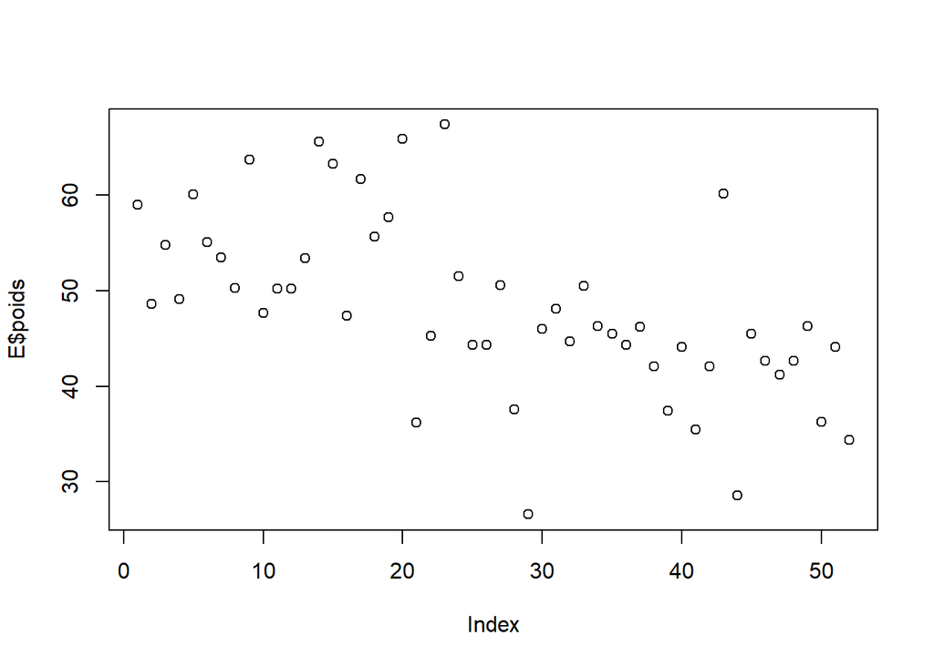

```r
### "ALLURES" (plot, histo, boxplot)

#### PLOT
plot(E$poids)
```

```r
##### MIEUX
couleurs <- ifelse(E$sexe == "F", "skyblue", "pink")
formes <- ifelse(E$sexe == "F", 16, 17)
E$poids
```

```
##  [1] 59.0 48.6 54.8 49.1 60.1 55.1 53.5 50.3 63.7 47.7 50.2 50.2 53.4 65.6 63.3 47.4 61.7 55.7 57.7
## [20] 65.9 36.2 45.3 67.4 51.5 44.3 44.3 50.6 37.6 26.6 46.0 48.1 44.7 50.5 46.3 45.5 44.3 46.2 42.1
## [39] 37.4 44.1 35.5 42.1 60.2 28.6 45.5 42.7 41.2 42.7 46.3 36.3 44.1 34.4
```

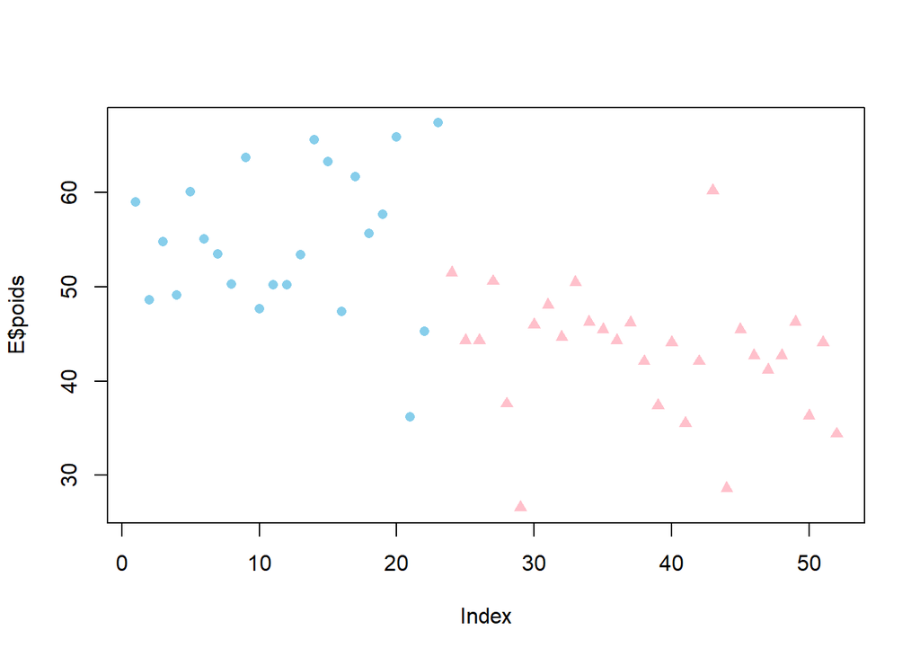

```r
plot(E$poids, col = couleurs, pch = formes)
```

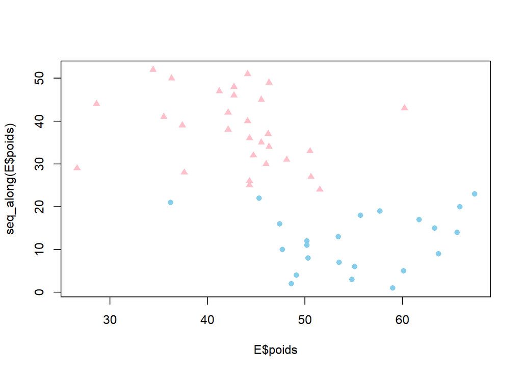

```r
##### INVERSER (=Intervetir les Axes)
plot(y = seq_along(E$poids), x = E$poids, col = couleurs, pch = formes)
```

```r
#### HISTO
hist(E$poids)
```

[output not shown]

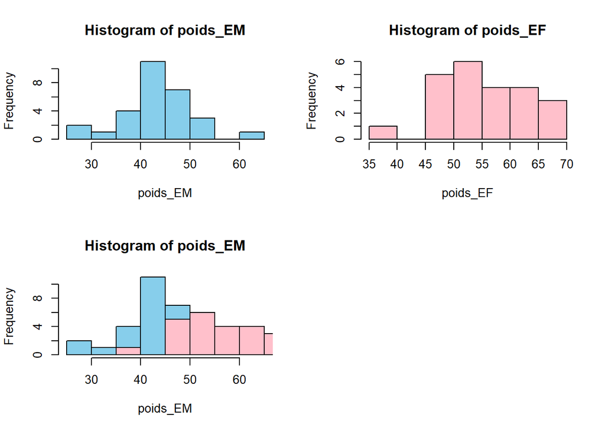

```r
##### MIEUX
poids_EF <- E$poids[E$sexe == "F"]
poids_EM <- E$poids[E$sexe == "M"]

par(mfrow = c(2, 2))  # Une rangée, deux colonnes

#####  Créer les histogrammes côte à côte
hist(poids_EM, col = "skyblue")
hist(poids_EF, col = "pink")

###### Faible intérêt superposé, ou alors, couleur transparente
hist(poids_EM, col = "skyblue")
hist(poids_EF, col = "pink", add = TRUE)  # Utiliser add = TRUE pour superposer

###### Faible intérêt mais plus propre :
# # library(ggplot2)
# ggplot(E, aes(x = poids, fill = sexe)) +
#     geom_histogram(alpha = 0.5, position = "identity", bins = 10) +
#     scale_fill_manual(values = c("F" = "pink", "M" = "skyblue"))



par(mfrow = c(1, 1)) # Reset la Fenêtre
```

#### BOXPLOTS

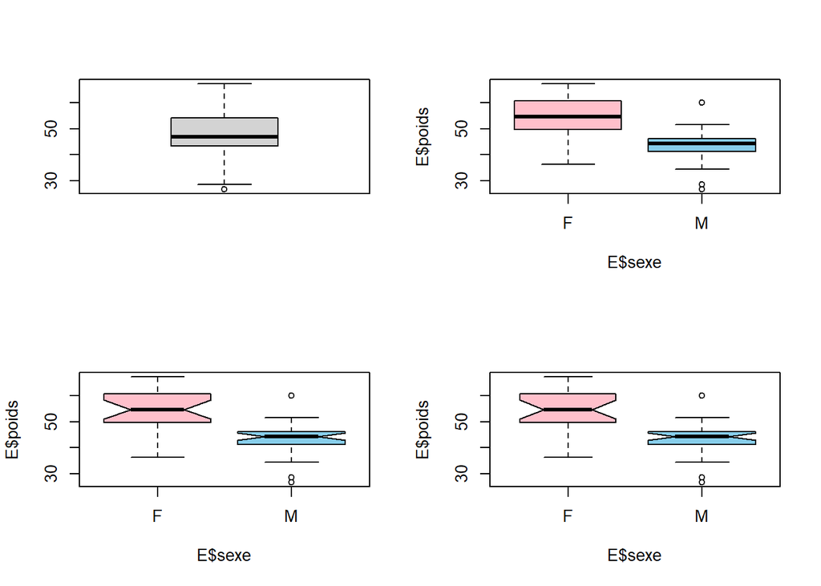

```r
par(mfrow = c(2, 2))  # Une rangée, deux colonnes
boxplot(E$poids)
boxplot(E$poids ~ E$sexe, col = c("pink", "skyblue"))
boxplot(E$poids ~ E$sexe, col = c("pink", "skyblue"), notch = TRUE) # IC95% ?
boxplot(
    E$poids ~ E$sexe,
    col = c("pink", "skyblue"),
    notch = TRUE,
    varwidth = TRUE # PROPORTIONNALITE à la TAILLE DE ECHANTILLON
)
```

##### Normalité des Distributions ?

###### Données Regroupées

```r
hist(E$poids)
```

[output not shown]

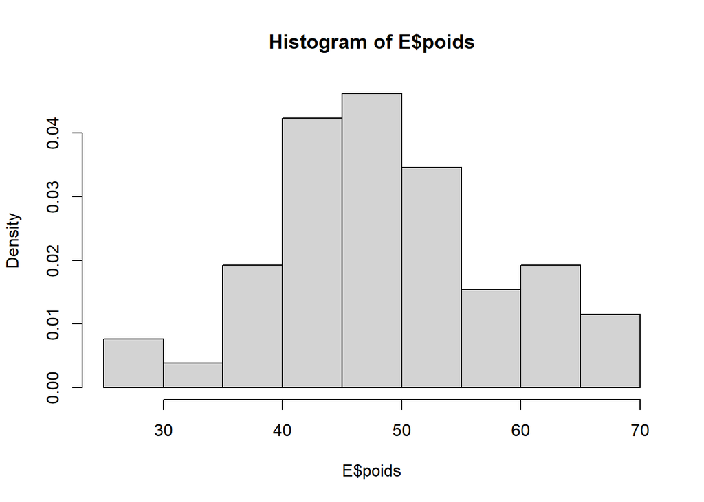

```r
hist(E$poids, proba=TRUE ) # Effectif => Proba
```

```r
hist(E$poids, nclass = 10  ) ## ??? Intérêt ?
```

[output not shown]

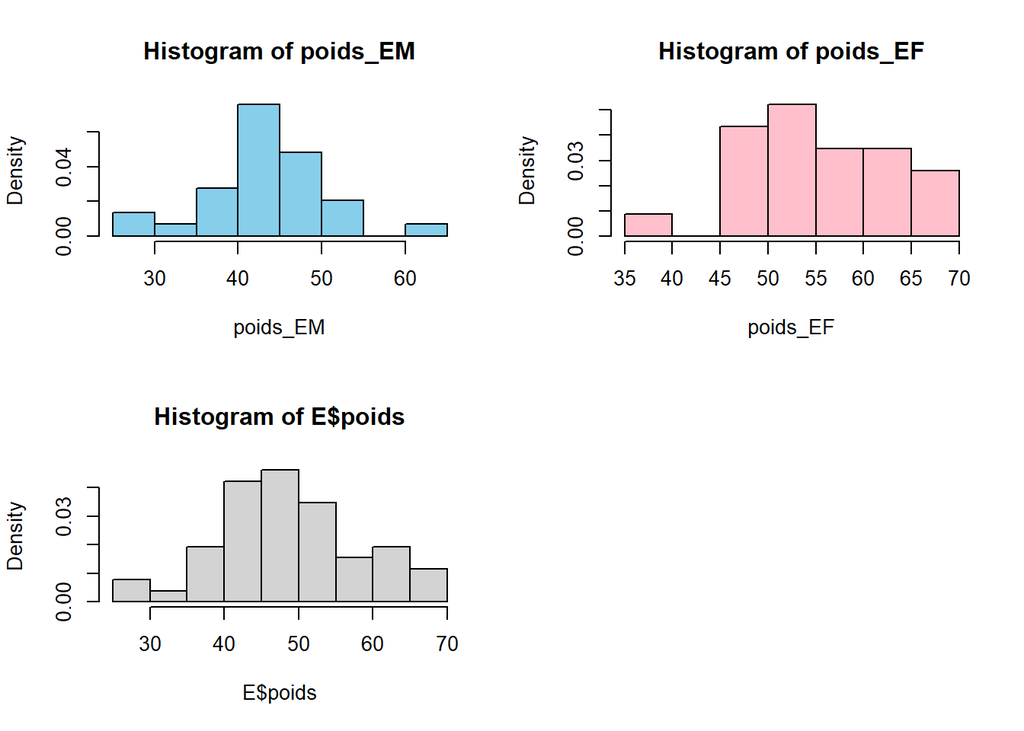

```r
par(mfrow = c(2, 2))  # Une rangée, deux colonnes

hist(poids_EM, col = "skyblue", proba=TRUE )
hist(poids_EF, col = "pink", proba=TRUE )
hist(E$poids, nclass = 10  , proba=TRUE) ## ??? Intérêt ?
```

```r
###### Normalité des Femelles ?
length(E$poids)
```

```
## [1] 52
```

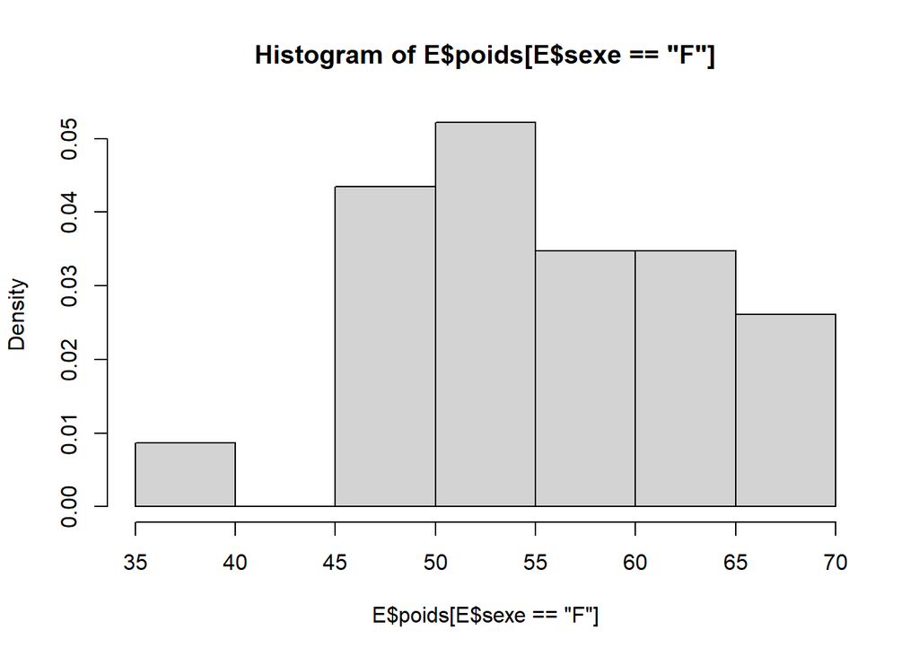

```r
hist(E$poids[E$sexe=="F"], proba=TRUE)
```

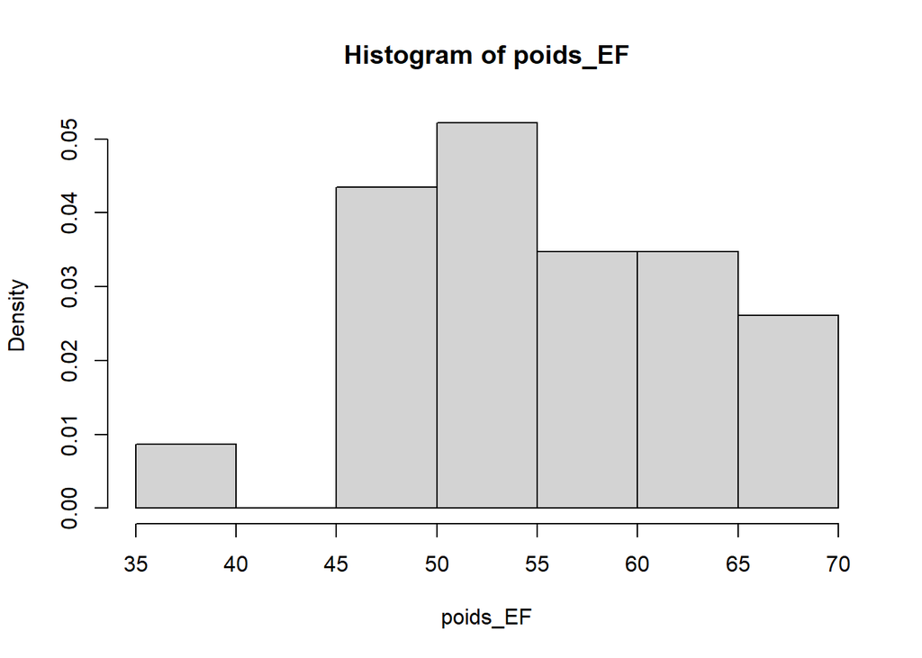

```r
####### POURQUOI DIFFERENT DE  #TODO PROF ???
poids_EF <- E$poids[E$sexe == "F"]
hist(poids_EF, proba=TRUE )
```

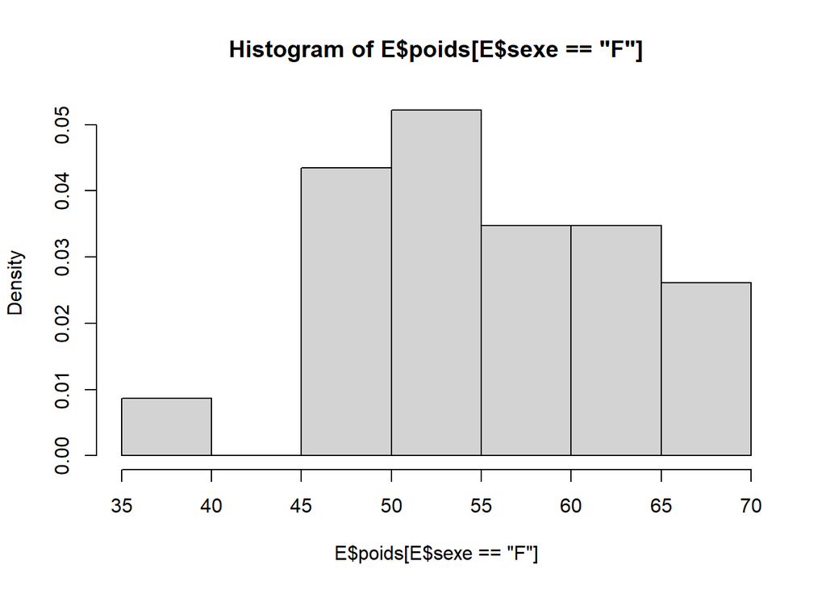

```r
hist(E$poids[E$sexe=="F"], proba=TRUE)
```

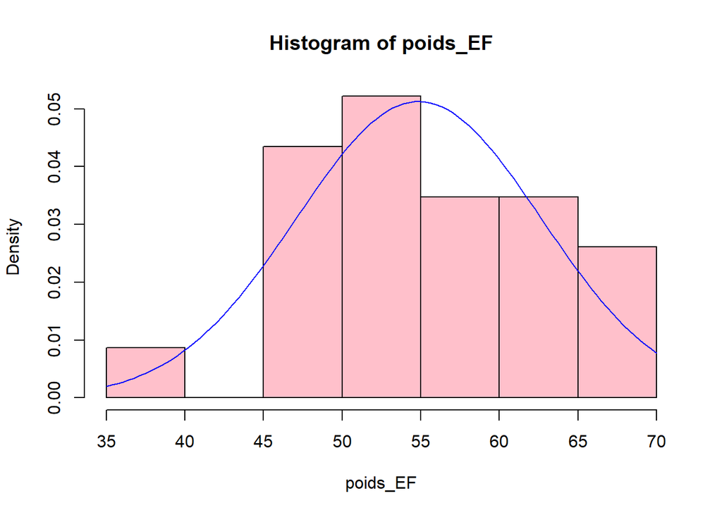

```r
hist(poids_EF, col = "pink", proba=TRUE )
curve(dnorm(x, mean (EF$poids), sd(EF$poids) ) , col="blue", add = TRUE) # (CORRECTION)
```

```r
####### AJOUTER la DEnsité d'une Loi Théorique
hist(poids_EF, col = "pink", proba=TRUE )
moy <- mean(poids_EF) ; moy
```

```
## [1] 54.86522
```

```r
ecart <- sd(poids_EF) ; ecart
```

```
## [1] 7.778619
```

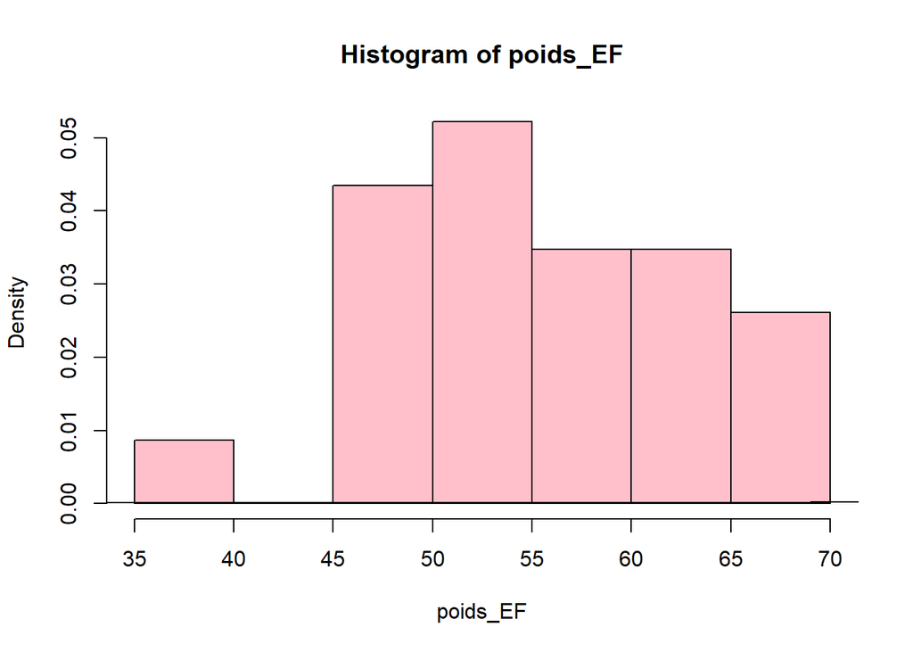

```r
x <- seq(25,75,length.out = 1000)
W_distribN <- dnorm(x, moy, ecart)
lines(W_distribN, main="25-75")
```

```r
######## Formule de la Fonction de la DENSITE ???
# curve(W_distribN) # Formule de la Fonction de la DENSITE ou DNORM ???
```

# LES TESTS

## SHAPIRO-WILK (VOIR LA CORRECTION => PROBLEMES !!) (FINIR MALES)

```
# H0 : Pas de Différence avec la Loi Normale
# H1 : (Différence qui n'est pas due au hasard...)
```

```r
shapiro.test(W_distribN) #=> p<0.05 => REJET = Positif => W ne suit pas une Loi Normale ?????
```

```
##
##  Shapiro-Wilk normality test
##
## data:  W_distribN
## W = 0.86456, p-value < 2.2e-16
```

```r
shapiro.test(poids_EF)# =p-value = 0.589 NORMALE...
```

```
##
##  Shapiro-Wilk normality test
##
## data:  poids_EF
## W = 0.96577, p-value = 0.589
```

```r
## HOMOSCEDASTICITE
```

```r
var.test(EF$poids, EM$poids)
```

```
##
##  F test to compare two variances
##
## data:  EF$poids and EM$poids
## F = 1.3146, num df = 22, denom df = 28, p-value = 0.4896
## alternative hypothesis: true ratio of variances is not equal to 1
## 95 percent confidence interval:
##  0.5973935 3.0093154
## sample estimates:
## ratio of variances
##           1.314614
```

```r
    # Il faut Comprendre chaque ligne de ce test !
```

## Fonction Variance Population

```r
var.echant <- function(vecteur){
  var.pop <- var(vecteur) * ((length(vecteur)-1)/length(vecteur))
  return(var.pop)
}
```

## B) Comparer Longueur des Rostres des Mâles des espèces P et E

Création d’un DF PEM

```r
PEM <- subset(bal, bal$sexe == "M" & (bal$espece == "E" | bal$espece == "P"))
# ou subset(bal$LR, bal$sexe == "M" & bal$espece %in% c("E", "P"))
PEM
```

|  | espece | sexe | poids | LR | LC | parasite |
| --- | --- | --- | --- | --- | --- | --- |
| 168 | E | M | 51.5 | 3.7 | 8.4 | 1 |
| 169 | E | M | 44.3 | 3.7 | 8.4 | 0 |
| 170 | E | M | 44.3 | 3.7 | 7.9 | 0 |
| 171 | E | M | 50.6 | 3.8 | 8.2 | 0 |
| 172 | E | M | 37.6 | 3.2 | 7.9 | 2 |
| 173 | E | M | 26.6 | 3.2 | 6.8 | 0 |
| 174 | E | M | 46.0 | 3.2 | 7.7 | 1 |
| 175 | E | M | 48.1 | 3.8 | 8.0 | 2 |
| 176 | E | M | 44.7 | 3.6 | 7.6 | 0 |
| 177 | E | M | 50.5 | 3.5 | 7.6 | 0 |

[output cut: 53 more lines]

Si je filtre LR => ### B1) Statistiques Descriptives Déterminer pour la Variable LR :  
* Médiane, moyenne, variance de l’échantillon  
* et variance estimée pour la population des mâles ches les 2 espèces :  
Espèces P : echant <- PM$LR

```r
echant <- PM$LR
length(echant)
```

```
## [1] 34
```

```r
median(echant)
```

```
## [1] 3.5
```

```r
mean(echant)
```

```
## [1] 3.476471
```

```r
var(echant)
```

```
## [1] 0.06609626
```

```r
var.echant(echant)
```

```
## [1] 0.06415225
```

Espèces E : echant <- EM$LR

```r
echant <- EM$LR
length(echant)
```

```
## [1] 29
```

```r
median(echant)
```

```
## [1] 3.7
```

```r
mean(echant)
```

```
## [1] 3.644828
```

```r
var(echant)
```

```
## [1] 0.04470443
```

```r
var.echant(echant)
```

```
## [1] 0.0431629
```

### B2) Normalité et égalité des Variances : Approche graphique et test

```r
formes <- ifelse(PEM$espece == "P", 16, 17)
PEM$LR
```

```
##  [1] 3.7 3.7 3.7 3.8 3.2 3.2 3.2 3.8 3.6 3.5 3.8 3.5 3.7 3.9 3.6 3.7 3.7 3.6 3.7 4.1 3.4 3.8 3.7 3.7
## [25] 3.8 3.9 3.6 3.7 3.4 3.4 3.8 3.3 3.5 3.7 3.1 3.3 3.3 3.4 3.7 3.7 3.4 3.1 3.5 3.5 3.7 3.8 3.8 3.5
## [49] 3.6 3.2 3.7 3.2 3.6 3.2 3.7 3.7 3.4 3.0 4.0 3.0 3.2 3.7 3.5
```

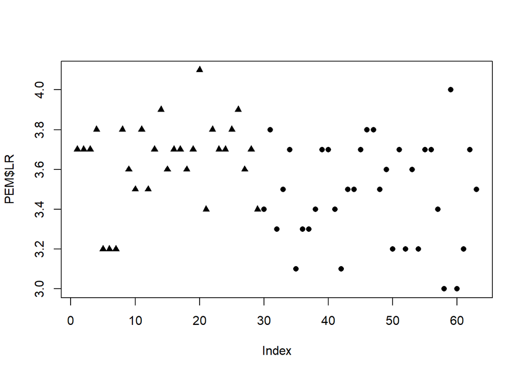

```r
plot(PEM$LR, pch = formes)
```

#### Normalité

```r
shapiro <- shapiro.test(EM$LR)
shapiro
```

```
##
##  Shapiro-Wilk normality test
##
## data:  EM$LR
## W = 0.91212, p-value = 0.01935
```

```r
shapiro.test(PM$LR)
```

```
##
##  Shapiro-Wilk normality test
##
## data:  PM$LR
## W = 0.9555, p-value = 0.1793
```

E : p-value = 0.01935 => Rejet H0 : Pas Normal P : p-value = 0.1793 => Accepte H0 : Normal

Pour faire Student, il faut la normalité des 2 échantillons.  
Or, E n’est pas normal donc on ne peut pas faire Student

# B3) TEST DE PERMUTATION

#### 1 Test de Student (Homogénéité des Moyennes)

```r
t.test(EM$LR, PM$LR, var.equal = T)
```

```
##
##  Two Sample t-test
##
## data:  EM$LR and PM$LR
## t = 2.8076, df = 61, p-value = 0.006694
## alternative hypothesis: true difference in means is not equal to 0
## 95 percent confidence interval:
##  0.04844966 0.28826434
## sample estimates:
## mean of x mean of y
##  3.644828  3.476471
```

```r
student <- t.test(EM$LR, PM$LR, var.equal = T)
student$statistic
```

```
##       t
## 2.80759
```

```r
t0 <- student$statistic
```

2. Le test de permutation pas à pas [,c(“LR”,“espece”)] : On récupère toutes les lignes (car rien avant la virgule) mais on ne sélectionne que 2 col : LR et Espèce. Equivalent à : subset(bal, sexe==“M” & espece (sexe==“E” | sexe==“P”) c(“E”,“P”))[,c(“LR”,“espece”)] à complèter par la sélection des colonnes

```r
MEP <- subset(bal, sexe=="M" & espece %in% c("E","P"))[,c("LR","espece")]
```

On obtient les Valeurs Filtrées…

1ère Simulation

```r
attach(MEP) # Toutes les Fonctions ensuite sont dans MEP : ALLEGE le CODE
```

```
## Les objets suivants sont masqués depuis MEP (pos = 3):
##
##     espece, LR
```

```
## Les objets suivants sont masqués depuis MEP (pos = 4):
##
##     espece, LR
```

```
## Les objets suivants sont masqués depuis MEP (pos = 5):
##
##     espece, LR
```

```r
# Quand on travaille toujours avec le meme objet
sample(espece) # Tirage aléatoire des Espèces (sans remise pour respecter la structure initiale : on ne change que l'ordre)
```

```
##  [1] P P P E E P E E P P E P E P P E P E P E P E E P P P P E P P P P P P E E E P P P P P E E P P P E
## [49] E E E P E E E E P P E E E E P
## Levels: E G P V
```

```r
table(sample(espece))
```

```
##
##  E  G  P  V
## 29  0 34  0
```

```r
tapply(LR, espece, mean) # On travaille bien avec les vrais données
```

```
##        E        G        P        V
## 3.644828       NA 3.476471       NA
```

```r
# Exemple : si on utilise : tapply(LR, sample(espece), mean) : On ne travaille plus avec notre jeu de données (l'objet MEP issu de BAL) mais avec un jeu de données aléatoire qui respecte la construction de notre jeu de données => Du coup, donne des moyennes différentes à chaque tirage : C'est ce qu'on va faire par la suite : et on va récupérer un distribution de 5000 tobs (à l'étape suivante)
tapply(LR, espece, var)
```

```
##          E          G          P          V
## 0.04470443         NA 0.06609626         NA
```

```r
# t.test(LR~(espece), var.equal=T)$statistic => idem au dessus sans répartition aléatoire
t.test(LR~sample(espece), var.equal=T)$statistic # LS en fonction de (~) ...
```

```
##          t
## -0.3664724
```

```r
t.test(LR~sample(espece), var.equal=T)$p.value
```

```
## [1] 0.505812
```

```r
LR~sample(espece)
```

```
## LR ~ sample(espece)
```

```r
t0 <- t.test(LR~(espece), var.equal=T)$statistic ; t0
```

```
##       t
## 2.80759
```

# Faire 5000 Simulations

On va stocker nos 5000 tobs pour pouvoir générer une distribution

```r
simult <- replicate(5000, t.test(LR~sample(espece), var.equal=T)$statistic)
```

Que contient l’objet simult ?

```r
head(simult)
```

```
##          t          t          t          t          t          t
## -0.9752115 -1.4957506 -1.2855803  0.4367817 -1.1815318  1.0470108
```

Représentation Graphique des 5000 tobs :

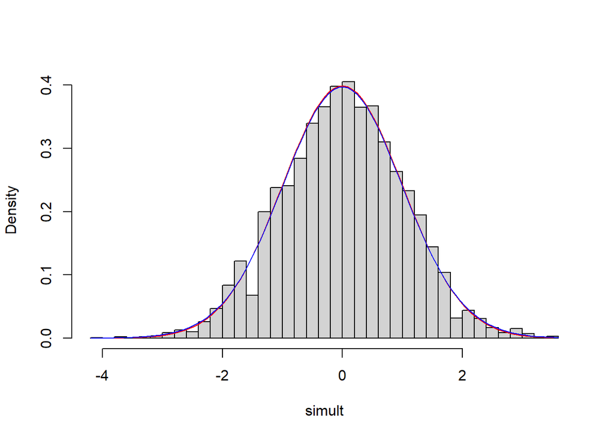

```r
par(mfrow=c(1,1)) # Partition de Fenetre
hist(simult, nclass=50, freq=FALSE, main="")
# Attention à bien recréer un x différent du précédent qui soit dans les mêmes bornes de notre distribution :
x <- seq(-4,4, le=200)
curve(dnorm(x), col="red", lwd=1, add=TRUE) # génère une Densité de Loi Normale
curve(dt(x,df=61), col="blue", lwd=1, add=TRUE) # Gènère une Densité de Student
```

Conclusion : Le Test T de Student est ROBUSTE à la NON NORMALITE de notre échantillon car la densité Normale et celle de notre densité de Student fait à partir de nos données rééchantillonées Mais attention, le degré de liberté va impacter sur le seuil de student qui va l’éloigner (augmentation de notre IC)

NB Importante : En fait, il faut savoir qu’on aura rarement un échantillon normale mais que STUDENT est toujours ROBUSTE à la NON NORMALITE SI la Distribution de l’échantillon est UNIMODALE ! (Donc on peut normalement de le faire même si la condition de Normalité n’est pas remplie)

# qqnorm() et qqplot()

## Un meilleur outil graphique pour rendre compte de cet ajustement est fournit par qqnorm() et qqplot() (NON FAIT POUR LE MOMENT EN TD)

# IMPORTANT :

Est-ce que la Vabs de l’objet dans simult est supérieur à t0 ? si oui, on le garde. ex : si on en a que 2 / 5000 observé on aura 2/5000 La fonction t() transpose les données lignes en colonne NB : Attention, on ne fait pas le somme des t mais du nb de fois où on est supérieur à t0

```r
sum(t(abs(simult))>t0)/length(simult)
```

```
## [1] 0.0076
```

# IDEE GENERALE :

On peut faire le Test de Permutation à chaque fois qu’on a un doute sur les conditions d’application, on peut faire des Tests de Permutation (pour tous les tests). Avant, sans Machine, on ne pouvait faire que des Tests NonP mais moins bien

# IV COMPARAISON DE DISTRIBUTION d’EFFECTIFS

## Test de CHI2 :

Tous les Tests de CHI2 sont des Tests de COMPARAISONS () Pourquoi on les utilise ? Quand on a des répartitions dans différentes modalités

- Chi2 d’ajustement : vérifier qu’une répartition suit une Loi (donc qd on a qu’1 seul échantillon)
- Chi2 d’indépendance : H0 : La répartition dans les sexes dépend de l’espèces
- Chi2 d’homogénéité : H0 : on aura la même répartition des sexes est la mmême pour toutes les espèces (Chi2 indépendance ou homogénéité sont pareils sauf qu’on formule H0 différement)

1> Le Sex-Raptio est-il homogène selon les espèces ?

```r
table(bal$espece, bal$sexe)
```

```
##
##      F  M
##   E 23 29
##   G 80 35
##   P 30 34
##   V 34 30
```

HO : Les Sexe Ratio est indépendant des Espèces (pas gagné d’après G dasn la Table)

```r
chisq.test(bal$espece, bal$sexe)
```

```
##
##  Pearson's Chi-squared test
##
## data:  bal$espece and bal$sexe
## X-squared = 13.888, df = 3, p-value = 0.003062
```

(être CAPABLE DE LE RECALCULER à LA MAIN) df = (Nb de ligne - 1) *( Nb de Colonne -1)

Conclusion Bio : La répartition des Sexes n’est pas Homogène suivant les Sexes ou … $expected => Donne els valeurs théorique

```r
chisq.test(bal$espece, bal$sexe)$expected
```

```
##           bal$sexe
## bal$espece        F        M
##          E 29.43729 22.56271
##          G 65.10169 49.89831
##          P 36.23051 27.76949
##          V 36.23051 27.76949
```

$residuals => Donne les Racines Carrés des Chi2 Partielles SIGNés : Si on s’écarte de l’attendu pour 1 espèce, on a un problème avec un modalité croisée

```r
chisq.test(bal$espece, bal$sexe)$residuals
```

```
##           bal$sexe
## bal$espece          F          M
##          E -1.1864626  1.3552122
##          G  1.8464635 -2.1090844
##          P -1.0351095  1.1823322
##          V -0.3705669  0.4232724
```

ici, on a donc un problème avec G…

# Important : Savoir Faire MOSAIC PLOT

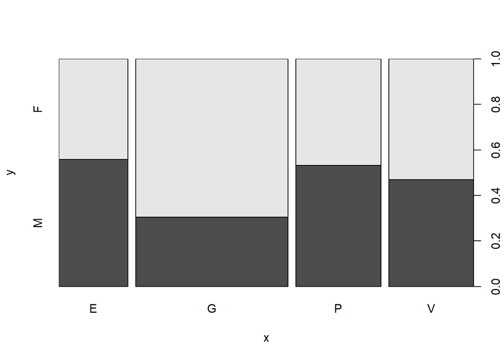

```r
plot(bal$espece,bal$sexe)
```

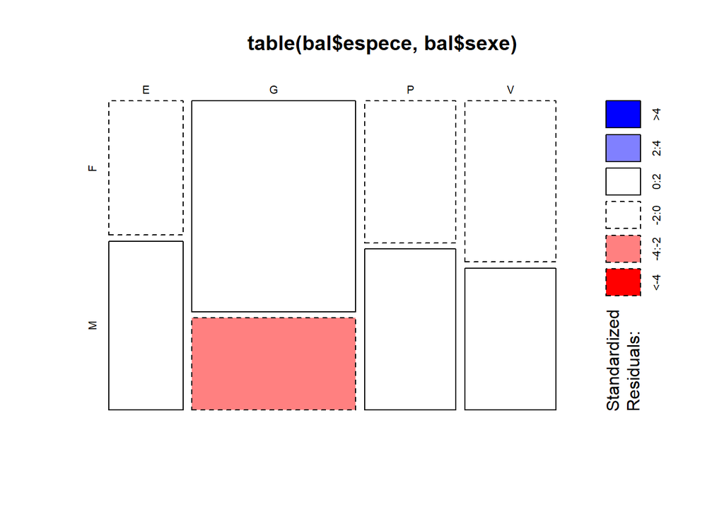

```r
mosaicplot(table(bal$espece, bal$sexe), shade = TRUE)
```

Seuls les Males de G sont colorés car cette modalité s’eloigne du 1.96 (2)

Comprendre comment est construite la Loi du Chi2 (carré (de la Variance) d’un VA d’un Loi Normale) pour 1 ddl, si on prend la somme des carres de 2 VA => DDL2… ….